# Practice H-D Model and Biomass with Tree Height

Nguyen-Le Xuan Bach

2025-12-29

# Preparation

## Packages

```r
library(tidyverse)
library(openxlsx) #read excel file
library(minpack.lm)
```

## Read data

```r
PinKre <- read.xlsx("Pinus_kremfii.xlsx", sheet = 1)
data_tree <- PinKre |>
  mutate(DBH = DBH_mm/10) # convert unit to cm
```

# Modeling the relationship between Diameter (DBH) and Height (H).

## Step 1: Exploratory Data Analysis (EDA)

The Scatter plot to visually assess the shape of the curve.

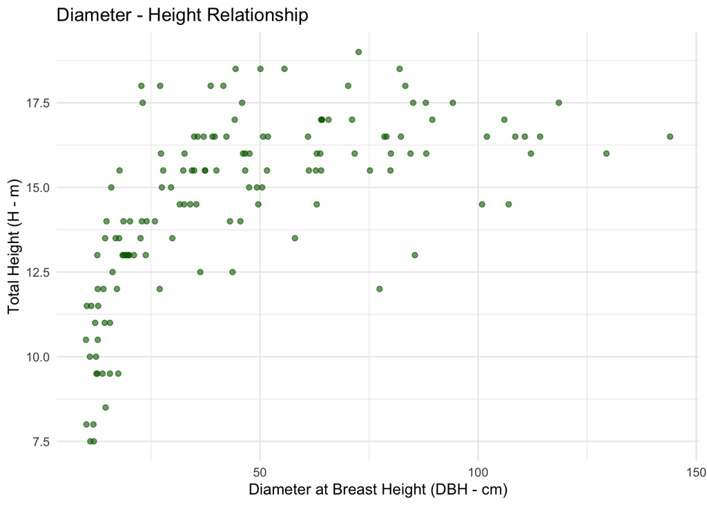

```r
# Plot the scatter diagram
ggplot(data_tree, aes(x = DBH, y = H)) +
  geom_point(alpha = 0.6, color = "darkgreen") +
  theme_minimal() +
  labs(title = "Diameter - Height Relationship",
       x = "Diameter at Breast Height (DBH - cm)",
       y = "Total Height (H - m)")
```

## Step 2: Selecting Ecological Models

There are many mathematical functions to describe the H-D relationship. The most common in forestry are: The Chapman-Richards function (also known as the generalized logistic function) is widely cited for modeling height-diameter (H-D) relationships in forestry, with key papers by Richards (1959) (for the original growth function) and numerous applications by researchers like Sharma & Parton (2007), Temesgen & Gadow (2004), Calama & Montero (2004), and more recent studies (e.g., Nazari Sendi et al., 2023, Ismail et al., 2025) demonstrating its versatility, often alongside mixed-effects modeling approaches for better accuracy across different species and forest conditions.

- **Chapman-Richards Function:** $H=1.3 + a.(1-e^{-b.DBH})^c$
  - 1.3 : Height at breast height.
  - a: Maximum height (Asymptote).
  - b: Growth rate.
  - c: Shape parameter of the curve.

  Find Maximum height

  ```r
  max(data_tree$H)
  ```

  ```
  ## [1] 19
  ```

### Step3: Running the Non-linear Model (`nls`)

We use the `nlsLM` function (from the `minpack.lm` package) instead of the standard `nls` in R because it uses the Levenberg-Marquardt algorithm, which helps find convergence more easily.

```r
# --- Model 2: Chapman-Richards ---
# Formula: H = 1.3 + a * (1 - exp(-b * DBH))^c
# Note: Choosing reasonable start values is crucial.
fit_cr <- nlsLM(H ~ 1.3 + a * (1 - exp(-b * DBH))^c,
                data = data_tree,
                start = list(a = 20, b = 0.05, c = 1))

# View results summary
summary(fit_cr)
```

```
##
## Formula: H ~ 1.3 + a * (1 - exp(-b * DBH))^c
##
## Parameters:
##   Estimate Std. Error t value Pr(>|t|)
## a 14.93814    0.20321  73.512  < 2e-16 ***
## b  0.10312    0.01869   5.518 1.71e-07 ***
## c  1.49447    0.43831   3.410  0.00086 ***
## ---
## Signif. codes:  0 '***' 0.001 '**' 0.01 '*' 0.05 '.' 0.1 ' ' 1
##
## Residual standard error: 1.503 on 134 degrees of freedom
##
## Number of iterations to convergence: 6
## Achieved convergence tolerance: 1.49e-08
```

### Step 4: Visualizing the Regression Curves

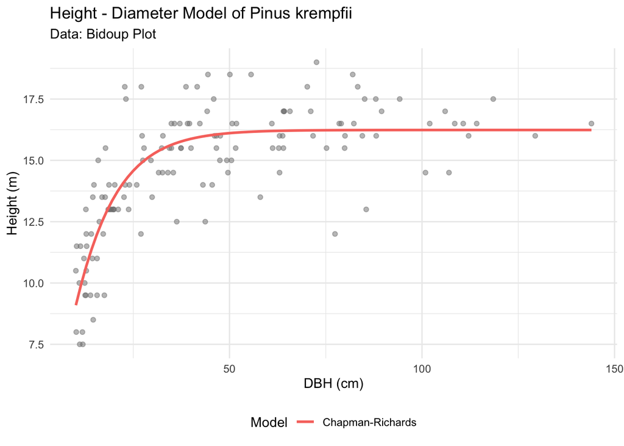

```r
# Create smooth prediction data
dbh_seq <- seq(min(data_tree$DBH), max(data_tree$DBH), length.out = 100)

# Predict values from the  models
pred_cr <- predict(fit_cr, newdata = data.frame(DBH = dbh_seq))

# Combine for plotting
plot_data <- data.frame(DBH = dbh_seq,
                        ChapmanRichards = pred_cr)

# Plot comparison
ggplot() +
  # Original data
  geom_point(data = data_tree, aes(x = DBH, y = H), alpha = 0.5, color = "gray50") +
  # Chapman-Richards line (Blue)
  geom_line(data = plot_data, aes(x = DBH, y = ChapmanRichards, color = "Chapman-Richards"), linewidth = 1) +
  labs(title = "Height - Diameter Model of Pinus krempfii",
       subtitle = "Data: Bidoup Plot",
       x = "DBH (cm)", y = "Height (m)",
       color = "Model") +
  theme_minimal() +
  theme(legend.position = "bottom")
```

# Biomass and carbon stock

## Biomass

- Above-ground biomass (AGB)
- Below-ground biomass (BGB)

### **AGB calculation**

Chave et al (2005). Tree allometry and improved estimation of carbon stocks and balance in tropical forests. Oecologia, 145(1): 87–99.

- AGB=Total aboveground biomass (kg)
- D=DBH (cm)
- H=Height (m)
- $ρ$=Wood density (g/cm3)
- BA=Basal area (cm2)

| Habitat | Equation in Chave et al (2005) |
| --- | --- |
| Tropical forest MOIST with Height | $AGB = exp(-2.977 + ln(ρ * D^2 * H))$ |
| Tropical forest MOIST only DBH | $AGB = ρ * exp(-1.499 + 2.148 * ln(D) + 0.207 * (ln(D))^2 – 0.0281 * (ln(D))^3)$ |

Get Wood density of Pinus krempfii

```r
library(BIOMASS)

woodensity <- getWoodDensity(
  genus = "Pinus",
  species = "Pinus krempfii",
  family = "Pinaceae"
)
woodensity
```

```
##     family genus        species    meanWD       sdWD levelWD nInd
## 1 Pinaceae Pinus Pinus krempfii 0.4402721 0.09413391   genus   57
```

Add Wood density to data

```r
data_tree$meanWD <- woodensity$meanWD
```

Biomass

```r
data_tree <- data_tree %>%
  mutate(AGB_onlyD = meanWD * exp(-1.499 + 2.148*log(DBH) + 0.207*log(DBH)^2 - 0.0281*log(DBH)^3),
         AGB_withH = exp(-2.977 + log(meanWD * DBH^2*H)))
```

```r
(AGB_onlyD <- sum(data_tree$AGB_onlyD)/1000) #Ton/ha
```

```
## [1] 376.3073
```

```r
(AGB_withH <- sum(data_tree$AGB_withH)/1000) #Ton/ha
```

```
## [1] 149.2933
```

### **BGB calculation**

The ratio developed by *Mokany et al. (2006). Critical analysis of root : shoot ratios in terrestrial biomes. Global Change Biology, 12: 84-96* offers specific ratios based on forest type and climate zone and are applicable when the aboveground biomass estimate (shoot) is reported at the stand level

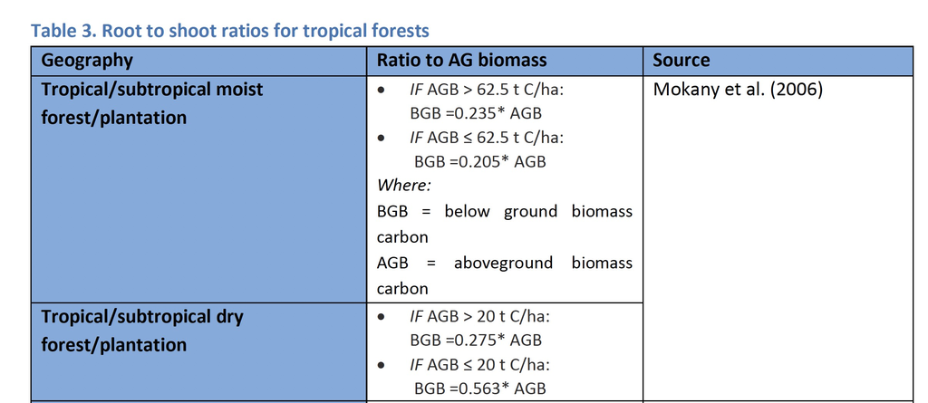

```r
(BGB_onlyD = 0.235 * AGB_onlyD)
```

```
## [1] 88.43222
```

```r
(BGB_withH = 0.235 * AGB_withH)
```

```
## [1] 35.08393
```

Total biomass of 1 hecta

```r
(TB_onlyD <- AGB_onlyD + BGB_onlyD)
```

```
## [1] 464.7395
```

```r
(TB_withH <- AGB_withH + BGB_withH)
```

```
## [1] 184.3772
```

## Carbon stock

```r
#Carbon stock (ton/ha)
(TC_onlyD <- TB_onlyD * 0.47)
```

```
## [1] 218.4276
```

```r
(TC_withH <- TB_withH * 0.47)
```

```
## [1] 86.65731
```

```r
# CO2 (ton)
(CO2_onlyD <- TC_onlyD * 44/22)
```

```
## [1] 436.8551
```

```r
(CO2_withH <- TC_withH * 44/22)
```

```
## [1] 173.3146
```